# mgt6203-Project-team103

# Decision Tree Regressor Models

Read the combined NBA and College dataset

```r
#read the cleaned and merged dataset
df <- read.csv("Dataset/nba_college_combined_dataset.csv", header = TRUE, sep = ",")

#head(df)
```

Initialize attributes with null values to zero (0)

```r
df[is.na(df)] <- 0

#check for null values in columns
sapply(df, function(x) sum(is.na(x)))
```

```
##              X college_Player      college_G     college_GS     college_MP
##              0              0              0              0              0
##     college_FG    college_FGA    college_FG.     college_2P    college_2PA
##              0              0              0              0              0
##    college_2P.     college_3P    college_3PA    college_3P.     college_FT
##              0              0              0              0              0
##    college_FTA    college_FT.    college_ORB    college_DRB    college_TRB
##              0              0              0              0              0
##    college_AST    college_STL    college_BLK    college_TOV     college_PF
##              0              0              0              0              0
##    college_PTS   college_Team          nba_G         nba_MP        nba_PER
##              0              0              0              0              0
##        nba_OWS        nba_DWS         nba_WS      nba_WS.48       nba_OBPM
##              0              0              0              0              0
##       nba_DBPM        nba_BPM       nba_VORP
##              0              0              0
```

Split the dataset into training(75%) and test(25%) sets

```r
#split of 75% of the data for training the model and 25% of the data to test the model
smp_size <- floor(0.75 * nrow(df))
set.seed(123)

train_ind <- sample(seq_len(nrow(df)), size = smp_size)
df_train <- df[train_ind, ]
df_test <- df[-train_ind, ]
```

### Train the Win Shares Decision Tree Regressor Model with selected college predictors

```r
# All College Predictors
# fit <- rpart(nba_WS ~ college_GS + college_MP + college_FG + college_FGA + college_FG. +
#                       college_2P + college_2PA + college_2P. + college_3P + college_3PA +
#                       college_3P. + college_FT + college_FTA + college_FT. + college_ORB +
#                       college_DRB + college_TRB + college_AST + college_STL + college_BLK +
#                       college_TOV + college_PF + college_PTS,
#              method = "anova", data = df_train)

#Variables from Mallow's CP variable selection for WinShare model
fit <- rpart(nba_WS ~ college_FG +  college_2P +    college_3P +    college_FTA +   college_FT. +
               college_TRB +    college_AST +   college_STL + college_BLK + college_PTS,
             method = "anova", data = df_train)
```

Plot the WinShare Decision Tree Regressor Model

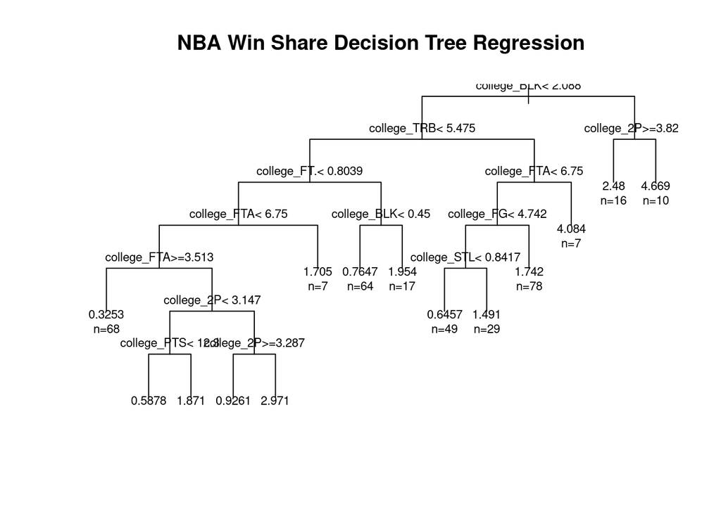

```r
# Plot
plot(fit, uniform = TRUE, main = "NBA Win Share Decision Tree Regression")
text(fit, use.n = TRUE, cex = .7)
```

Predict using the generated WinShare Decision Tree Regressor Model

```r
#Make predictions on the test dataset
prediction <- predict(fit, df_test, method = "anova")

results_df <- data.frame(df_test$nba_WS, prediction)
#results_df

results_df$difference <- round(results_df$df_test.nba_WS - results_df$prediction,2)

MAE = mean(abs(results_df$difference))
print(paste("Mean Absolute Error (MAE) is: ", round(MAE, 3)))
```

```
## [1] "Mean Absolute Error (MAE) is:  1.106"
```

```r
SSE = sum(results_df$difference**2)
print(paste("Sum of Squared Errors (SSE) is:", round(SSE, 3)))
```

```
## [1] "Sum of Squared Errors (SSE) is: 465.126"
```

### Train VORP Decision Tree Regressor Model with selected college predictors

```r
#All College Data
# fit_vorp <- rpart(nba_WS ~ college_GS + college_MP + college_FG + college_FGA + college_FG. + college_2P + college_2PA + college_2P. +
#                            college_3P + college_3PA + college_3P. + college_FT + college_FTA + college_FT. + college_ORB + college_DRB +     #                            college_TRB + college_AST + college_STL + college_BLK + college_TOV + college_PF + college_PTS,
#              method = "anova", data = df_train)

#Variables from Mallow's CP variable selection model 1 (two models tied with cp = 9)
# fit_vorp <- rpart(nba_VORP ~ college_FG + college_2P +    college_3P +    college_3PA +   college_3P. +   college_FT +    college_FTA +   college_DRB +
#                              college_TRB +    college_AST +   college_STL +   college_BLK +   college_TOV +   college_PTS,
#              method = "anova", data = df_train)

#Variables from Mallow's CP variable selection model 2 (two models tied with cp = 9)
fit_vorp <- rpart(nba_VORP ~ college_MP +   college_FG +    college_2P +    college_3P +    college_3PA +   college_3P. +   college_FT +    college_FTA +
                             college_DRB +  college_TRB +   college_AST +   college_STL +   college_BLK +   college_TOV,
                  method = "anova", data = df_train)
```

Plot the VORP Decision Tree Regressor Model

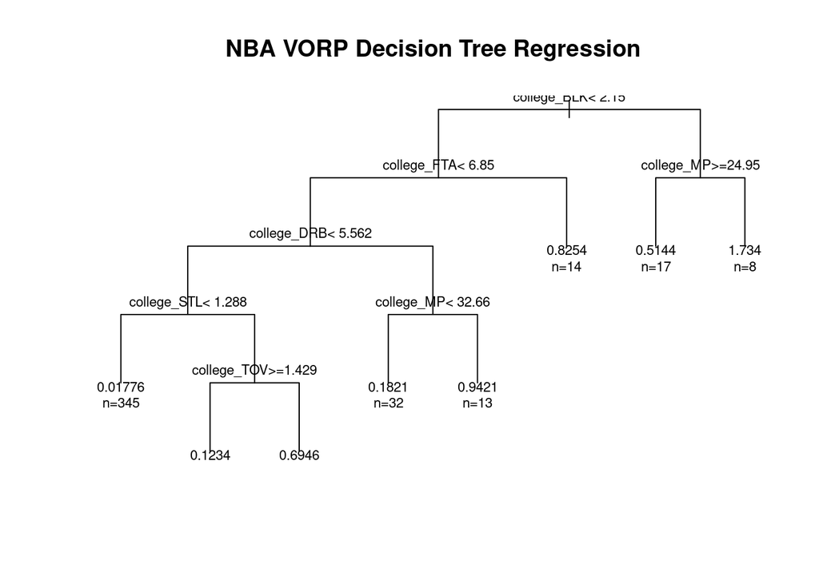

```r
# Plot
plot(fit_vorp, uniform = TRUE,
     main = "NBA VORP Decision Tree Regression")
text(fit_vorp, use.n = TRUE, cex = .7)
```

Predict using the generated VORP Decision Tree Regressor Model

```r
#Make predictions on the test dataset
prediction <- predict(fit_vorp, df_test, method = "anova")

results_df <- data.frame(df_test$nba_VORP, prediction)
#results_df

results_df$difference <- round(results_df$df_test.nba_VORP - results_df$prediction,2)

MAE = mean(abs(results_df$difference))
print(paste("Mean Absolute Error (MAE) is: ", round(MAE, 3)))
```

```
## [1] "Mean Absolute Error (MAE) is:  0.338"
```

```r
SSE = sum(results_df$difference**2)
print(paste("Sum of Squared Errors (SSE) is:", round(SSE, 3)))
```

```
## [1] "Sum of Squared Errors (SSE) is: 61.865"
```

# Linear Regression Models

Read the combined NBA and College dataset.

```r
#read the cleaned and merged dataset
nba_college_data <- read.csv("Dataset/nba_college_combined_dataset.csv", header = TRUE, sep = ",")

#head(nba_college_data)
```

Initialize attributes with null values to the mean column value

```r
#impute null column items with the mean value for the column
nba_college_data$college_FG.[is.na(nba_college_data$college_FG.)] <- mean(nba_college_data$college_FG., na.rm = TRUE)
nba_college_data$college_2P.[is.na(nba_college_data$college_2P.)] <- mean(nba_college_data$college_2P., na.rm = TRUE)
nba_college_data$college_3P.[is.na(nba_college_data$college_3P.)] <- mean(nba_college_data$college_3P., na.rm = TRUE)
nba_college_data$college_FT.[is.na(nba_college_data$college_FT.)] <- mean(nba_college_data$college_FT., na.rm = TRUE)

#check for null values in columns
sapply(nba_college_data, function(x) sum(is.na(x)))
```

```
##              X college_Player      college_G     college_GS     college_MP
##              0              0              0              0              0
##     college_FG    college_FGA    college_FG.     college_2P    college_2PA
##              0              0              0              0              0
##    college_2P.     college_3P    college_3PA    college_3P.     college_FT
##              0              0              0              0              0
##    college_FTA    college_FT.    college_ORB    college_DRB    college_TRB
##              0              0              0              0              0
##    college_AST    college_STL    college_BLK    college_TOV     college_PF
##              0              0              0              0              0
##    college_PTS   college_Team          nba_G         nba_MP        nba_PER
##              0              0              0              0              0
##        nba_OWS        nba_DWS         nba_WS      nba_WS.48       nba_OBPM
##              0              0              0              0              0
##       nba_DBPM        nba_BPM       nba_VORP
##              0              0              0
```

```r
#check correleation between college predictors and response variables nba_WS, nba_WS.48 and nba_VORP
#ggpairs(nba_college_data, columns = c("college_G","college_GS","college_MP","college_2P","college_2PA","college_2P.",
#                                      "college_3P","college_3PA","college_3P.","college_FT", "college_FTA","college_FT.",
#                                      "college_FG", "college_FGA","college_FG.","college_ORB","college_DRB","college_TRB",
#                                      "college_STL","college_AST", "college_BLK", "college_TOV", "college_PF","college_PTS",
#                                      "nba_WS", "nba_WS.48", "nba_VORP"),
#        columnLabels = c("G", "GS", "Minutes Played", "2-Pt", "2-Pt At", "2-Pt%", "3-Pt", "3-Pt At", "3-Pt%", "FT", "FT At",
#                         "FT%", "FG", "FG At", "FG%", "ORB", "DRB", "TRB", "STL", "AST", "BLK", "TOV", "PF", "PTS", "WS", "WS.48", "VORP"),
#        mapping=ggplot2::aes(color= "cyan"))

#cor(nba_college_data[, c("college_G","college_GS","college_MP","college_2P","college_2PA","college_2P.", "college_3P","college_3PA","college_3P.","college_FT", "college_FTA","college_FT.", "college_FG", "college_FGA","college_FG.","college_ORB","college_DRB","college_TRB", "college_STL","college_AST", "college_BLK", "college_TOV", "college_PF","college_PTS","nba_WS", "nba_WS.48", "nba_VORP")], method="pearson")
```

Create a subset of data to train the regression models with all college predictors

```r
m <- dim(nba_college_data)[1]

sample_size <- sample(m, size = 0.75*m)

# create a subset of data to run stepwise regression for variable selection
player_subset_1 <- as.data.frame(nba_college_data[sample_size,])

# create a subset of data to re-run linear regression with selected variables
player_subset_2 <- as.data.frame(nba_college_data[-sample_size,])
```

Fit a model for each of the response variables, WinShare(nba_WS) and VORP(nba_VORP), using all college predictors except the factors (college_player” & “college_team”). Run bidirectional stepwise regression (forward and backward) to find the best models for WS and VORP (model with the least AIC score)

```r
#generate linear regression model with WinShare as the response variable and college data predictors
model_WS <- lm(nba_WS~college_G+college_GS+college_MP+college_FG+
                      college_FGA+college_2P+college_2PA+college_3P+college_3PA+
                      college_FT+college_FTA+college_ORB+college_DRB+college_TRB+
                      college_AST+college_STL+college_BLK+college_TOV+college_PF+
                      college_PTS+college_2P.+college_3P.+college_FT.+college_FG.,
                data=as.data.frame(player_subset_1))

summary(model_WS)
```

```
##
## Call:
## lm(formula = nba_WS ~ college_G + college_GS + college_MP + college_FG +
##     college_FGA + college_2P + college_2PA + college_3P + college_3PA +
##     college_FT + college_FTA + college_ORB + college_DRB + college_TRB +
##     college_AST + college_STL + college_BLK + college_TOV + college_PF +
##     college_PTS + college_2P. + college_3P. + college_FT. + college_FG.,
##     data = as.data.frame(player_subset_1))
##
## Residuals:
##     Min      1Q  Median      3Q     Max
## -3.4771 -0.8835 -0.3256  0.4743  8.3994
##
## Coefficients:
##             Estimate Std. Error t value Pr(>|t|)
## (Intercept)  3.07185    1.28105   2.398 0.016863 *
## college_G   -0.07113    0.03488  -2.039 0.041974 *
## college_GS   0.02143    0.02494   0.859 0.390542
## college_MP  -0.02782    0.02660  -1.046 0.296271
## college_FG  -0.86972    2.80485  -0.310 0.756635
## college_FGA -6.12854    1.79676  -3.411 0.000701 ***
## college_2P  -1.33178    1.96477  -0.678 0.498198
## college_2PA  5.75947    1.79598   3.207 0.001430 **
## college_3P  -2.95524    2.43596  -1.213 0.225649
## college_3PA  6.04349    1.78916   3.378 0.000789 ***
## college_FT  -1.00040    1.21416  -0.824 0.410370
## college_FTA -0.16026    0.25068  -0.639 0.522918
## college_ORB -0.18687    1.73030  -0.108 0.914041
## college_DRB -0.59404    1.73076  -0.343 0.731577
## college_TRB  0.65441    1.72646   0.379 0.704815
## college_AST  0.37131    0.07749   4.792  2.2e-06 ***
## college_STL  0.28229    0.18394   1.535 0.125508
## college_BLK  0.31115    0.13429   2.317 0.020914 *
## college_TOV -0.63308    0.16973  -3.730 0.000214 ***
## college_PF  -0.03824    0.14963  -0.256 0.798407
## college_PTS  1.43425    1.17498   1.221 0.222805
## college_2P. -2.04591    1.63264  -1.253 0.210757
## college_3P. -1.26151    0.91142  -1.384 0.166956
## college_FT. -1.36039    1.11946  -1.215 0.224868
## college_FG.  1.21144    2.57379   0.471 0.638076
## ---
## Signif. codes:  0 '***' 0.001 '**' 0.01 '*' 0.05 '.' 0.1 ' ' 1
##
## Residual standard error: 1.408 on 489 degrees of freedom
## Multiple R-squared:  0.1891, Adjusted R-squared:  0.1493
## F-statistic: 4.753 on 24 and 489 DF,  p-value: 4.55e-12
```

Variable selection using step()

```r
step(model_WS, direction="both")
```

```
## Start:  AIC=376.42
## nba_WS ~ college_G + college_GS + college_MP + college_FG + college_FGA +
##     college_2P + college_2PA + college_3P + college_3PA + college_FT +
##     college_FTA + college_ORB + college_DRB + college_TRB + college_AST +
##     college_STL + college_BLK + college_TOV + college_PF + college_PTS +
##     college_2P. + college_3P. + college_FT. + college_FG.
##
##               Df Sum of Sq     RSS    AIC
## - college_ORB  1     0.023  970.01 374.43
## - college_PF   1     0.130  970.11 374.49
## - college_FG   1     0.191  970.17 374.52
## - college_DRB  1     0.234  970.22 374.54
## - college_TRB  1     0.285  970.27 374.57
## - college_FG.  1     0.439  970.42 374.65
## - college_FTA  1     0.811  970.79 374.85
## - college_2P   1     0.911  970.90 374.90
## - college_FT   1     1.347  971.33 375.13
## - college_GS   1     1.465  971.45 375.19
## - college_MP   1     2.169  972.15 375.57
## - college_3P   1     2.919  972.90 375.96
## - college_FT.  1     2.929  972.91 375.97
## - college_PTS  1     2.956  972.94 375.98
## - college_2P.  1     3.115  973.10 376.07
## <none>                      969.98 376.42
## - college_3P.  1     3.800  973.78 376.43
## - college_STL  1     4.672  974.66 376.89
## - college_G    1     8.248  978.23 378.77
## - college_BLK  1    10.649  980.63 380.03
## - college_2PA  1    20.399  990.38 385.12
## - college_3PA  1    22.633  992.62 386.27
## - college_FGA  1    23.078  993.06 386.50
## - college_TOV  1    27.598  997.58 388.84
## - college_AST  1    45.541 1015.53 398.00
##
## Step:  AIC=374.43
## nba_WS ~ college_G + college_GS + college_MP + college_FG + college_FGA +
##     college_2P + college_2PA + college_3P + college_3PA + college_FT +
##     college_FTA + college_DRB + college_TRB + college_AST + college_STL +
##     college_BLK + college_TOV + college_PF + college_PTS + college_2P. +
##     college_3P. + college_FT. + college_FG.
```

[output cut: 407 more lines]

```
## + college_PF   1     0.026  987.26 361.49
## + college_FG   1     0.009  987.27 361.50
## + college_FT   1     0.003  987.28 361.50
## + college_FG.  1     0.002  987.28 361.50
## - college_3P.  1     7.761  995.04 361.53
## - college_G    1    10.433  997.72 362.91
## - college_BLK  1    11.490  998.77 363.45
## - college_DRB  1    12.994 1000.28 364.23
## - college_2PA  1    23.462 1010.74 369.58
## - college_3PA  1    24.007 1011.29 369.85
## - college_FGA  1    25.572 1012.85 370.65
## - college_TRB  1    26.158 1013.44 370.95
## - college_TOV  1    32.947 1020.23 374.38
## - college_PTS  1    35.939 1023.22 375.88
## - college_AST  1    68.892 1056.17 392.17
```

```
##
## Call:
## lm(formula = nba_WS ~ college_G + college_FGA + college_2PA +
##     college_3PA + college_DRB + college_TRB + college_AST + college_BLK +
##     college_TOV + college_PTS + college_3P., data = as.data.frame(player_subset_1))
##
## Coefficients:
## (Intercept)    college_G  college_FGA  college_2PA  college_3PA  college_DRB
##     1.55740     -0.06638     -6.36901      6.08649      6.16613     -0.46832
## college_TRB  college_AST  college_BLK  college_TOV  college_PTS  college_3P.
##     0.49981      0.38190      0.30794     -0.61133      0.22717     -1.55712
```

```r
#generate linear regression model with VORP as the response variable and college data predictors
model_VORP <- lm(nba_VORP~college_G+college_GS+college_MP+college_FG+
                          college_FGA+college_2P+college_2PA+college_3P+college_3PA+
                          college_FT+college_FTA+college_ORB+college_DRB+college_TRB+
                          college_AST+college_STL+college_BLK+college_TOV+college_PF+
                          college_PTS+college_2P.+college_3P.+college_FT.+college_FG.,
                  data=as.data.frame(player_subset_1))

summary(model_VORP)
```

```
##
## Call:
## lm(formula = nba_VORP ~ college_G + college_GS + college_MP +
##     college_FG + college_FGA + college_2P + college_2PA + college_3P +
##     college_3PA + college_FT + college_FTA + college_ORB + college_DRB +
##     college_TRB + college_AST + college_STL + college_BLK + college_TOV +
##     college_PF + college_PTS + college_2P. + college_3P. + college_FT. +
##     college_FG., data = as.data.frame(player_subset_1))
##
## Residuals:
##     Min      1Q  Median      3Q     Max
## -1.6018 -0.2868 -0.1109  0.1436  4.1817
##
## Coefficients:
##              Estimate Std. Error t value Pr(>|t|)
## (Intercept)  1.235085   0.528369   2.338 0.019814 *
## college_G   -0.020068   0.014387  -1.395 0.163677
## college_GS   0.006455   0.010286   0.627 0.530633
## college_MP  -0.029324   0.010972  -2.673 0.007778 **
## college_FG   0.442186   1.156858   0.382 0.702456
## college_FGA -2.608612   0.741073  -3.520 0.000472 ***
## college_2P  -0.554462   0.810367  -0.684 0.494166
## college_2PA  2.497358   0.740750   3.371 0.000807 ***
## college_3P  -0.682003   1.004710  -0.679 0.497582
## college_3PA  2.563814   0.737938   3.474 0.000558 ***
## college_FT   0.074159   0.500779   0.148 0.882336
## college_FTA -0.135313   0.103392  -1.309 0.191240
## college_ORB -0.009247   0.713662  -0.013 0.989667
## college_DRB -0.086447   0.713852  -0.121 0.903662
## college_TRB  0.162638   0.712078   0.228 0.819431
## college_AST  0.161489   0.031961   5.053 6.17e-07 ***
## college_STL  0.234079   0.075866   3.085 0.002148 **
## college_BLK  0.140192   0.055386   2.531 0.011680 *
## college_TOV -0.220082   0.070004  -3.144 0.001769 **
## college_PF  -0.082873   0.061713  -1.343 0.179935
## college_PTS  0.162131   0.484622   0.335 0.738107
## college_2P. -0.995082   0.673381  -1.478 0.140121
## college_3P. -0.831103   0.375916  -2.211 0.027507 *
## college_FT. -0.433855   0.461720  -0.940 0.347862
## college_FG.  0.538414   1.061559   0.507 0.612249
## ---
## Signif. codes:  0 '***' 0.001 '**' 0.01 '*' 0.05 '.' 0.1 ' ' 1
##
## Residual standard error: 0.5809 on 489 degrees of freedom
## Multiple R-squared:  0.1853, Adjusted R-squared:  0.1453
## F-statistic: 4.635 on 24 and 489 DF,  p-value: 1.15e-11
```

Variable selection using step()

```r
step(model_VORP, direction="both")
```

```
## Start:  AIC=-534.02
## nba_VORP ~ college_G + college_GS + college_MP + college_FG +
##     college_FGA + college_2P + college_2PA + college_3P + college_3PA +
##     college_FT + college_FTA + college_ORB + college_DRB + college_TRB +
##     college_AST + college_STL + college_BLK + college_TOV + college_PF +
##     college_PTS + college_2P. + college_3P. + college_FT. + college_FG.
##
##               Df Sum of Sq    RSS     AIC
## - college_ORB  1    0.0001 165.01 -536.02
## - college_DRB  1    0.0049 165.01 -536.00
## - college_FT   1    0.0074 165.02 -536.00
## - college_TRB  1    0.0176 165.03 -535.97
## - college_PTS  1    0.0378 165.05 -535.90
## - college_FG   1    0.0493 165.06 -535.87
## - college_FG.  1    0.0868 165.09 -535.75
## - college_GS   1    0.1329 165.14 -535.61
## - college_3P   1    0.1555 165.16 -535.54
## - college_2P   1    0.1580 165.17 -535.53
## - college_FT.  1    0.2979 165.31 -535.09
## - college_FTA  1    0.5780 165.59 -534.22
## - college_PF   1    0.6085 165.62 -534.13
## <none>                     165.01 -534.02
## - college_G    1    0.6566 165.66 -533.98
## - college_2P.  1    0.7369 165.75 -533.73
## - college_3P.  1    1.6494 166.66 -530.91
## - college_BLK  1    2.1619 167.17 -529.33
## - college_MP   1    2.4103 167.42 -528.57
## - college_STL  1    3.2124 168.22 -526.11
## - college_TOV  1    3.3352 168.34 -525.73
## - college_2PA  1    3.8355 168.84 -524.21
## - college_3PA  1    4.0732 169.08 -523.49
## - college_FGA  1    4.1811 169.19 -523.16
## - college_AST  1    8.6145 173.62 -509.86
##
## Step:  AIC=-536.02
## nba_VORP ~ college_G + college_GS + college_MP + college_FG +
##     college_FGA + college_2P + college_2PA + college_3P + college_3PA +
##     college_FT + college_FTA + college_DRB + college_TRB + college_AST +
##     college_STL + college_BLK + college_TOV + college_PF + college_PTS +
##     college_2P. + college_3P. + college_FT. + college_FG.
```

[output cut: 375 more lines]

```
## + college_FTA  1    0.0312 167.29 -548.95
## + college_GS   1    0.0100 167.31 -548.89
## + college_FG   1    0.0065 167.32 -548.88
## + college_FT   1    0.0000 167.32 -548.86
## - college_3P.  1    1.5102 168.83 -548.24
## - college_BLK  1    2.5119 169.84 -545.20
## - college_PTS  1    3.4842 170.81 -542.26
## - college_STL  1    3.5577 170.88 -542.04
## - college_TOV  1    3.9384 171.26 -540.90
## - college_MP   1    4.0680 171.39 -540.51
## - college_2PA  1    4.3270 171.65 -539.73
## - college_3PA  1    4.4118 171.74 -539.48
## - college_FGA  1    4.5527 171.88 -539.06
## - college_TRB  1    6.9537 174.28 -531.93
## - college_AST  1    8.5280 175.85 -527.31
```

```
##
## Call:
## lm(formula = nba_VORP ~ college_MP + college_FGA + college_2PA +
##     college_3PA + college_TRB + college_AST + college_STL + college_BLK +
##     college_TOV + college_PF + college_PTS + college_3P., data = as.data.frame(player_subset_1))
##
## Coefficients:
## (Intercept)   college_MP  college_FGA  college_2PA  college_3PA  college_TRB
##     0.44486     -0.03038     -2.68852      2.61551      2.64557      0.09316
## college_AST  college_STL  college_BLK  college_TOV   college_PF  college_PTS
##     0.15406      0.23902      0.14517     -0.22452     -0.10013      0.07082
## college_3P.
##    -0.69022
```

Split the dataset into training(75%) and test(25%) sets

```r
m <- dim(nba_college_data)[1]

sample_size <- sample(m, size = 0.75*m)

train_data <- as.data.frame(nba_college_data[sample_size,]) # create a 75% training dataset
test_data <-as.data.frame(nba_college_data[-sample_size,])  # create a 25% test dataset
```

```r
newmodel_WS <- lm(formula = nba_WS ~ college_G + college_FGA + college_2PA + college_3P + college_3PA +
                                     college_DRB + college_TRB + college_AST + college_STL + college_BLK +
                                     college_TOV + college_PTS,
                  data = as.data.frame(train_data))

summary(newmodel_WS)
```

```
##
## Call:
## lm(formula = nba_WS ~ college_G + college_FGA + college_2PA +
##     college_3P + college_3PA + college_DRB + college_TRB + college_AST +
##     college_STL + college_BLK + college_TOV + college_PTS, data = as.data.frame(train_data))
##
## Residuals:
##     Min      1Q  Median      3Q     Max
## -3.1804 -0.8892 -0.4094  0.5549  7.4941
##
## Coefficients:
##             Estimate Std. Error t value Pr(>|t|)
## (Intercept)  0.63805    0.47556   1.342 0.180302
## college_G   -0.04369    0.03081  -1.418 0.156817
## college_FGA -4.49284    1.93352  -2.324 0.020543 *
## college_2PA  4.32150    1.92576   2.244 0.025265 *
## college_3P  -0.39111    0.46970  -0.833 0.405414
## college_3PA  4.44663    1.93493   2.298 0.021968 *
## college_DRB -0.31631    0.18575  -1.703 0.089215 .
## college_TRB  0.38307    0.14268   2.685 0.007495 **
## college_AST  0.20734    0.07333   2.828 0.004879 **
## college_STL  0.33763    0.17898   1.886 0.059825 .
## college_BLK  0.15543    0.12802   1.214 0.225283
## college_TOV -0.54314    0.15692  -3.461 0.000584 ***
## college_PTS  0.17476    0.06070   2.879 0.004160 **
## ---
## Signif. codes:  0 '***' 0.001 '**' 0.01 '*' 0.05 '.' 0.1 ' ' 1
##
## Residual standard error: 1.466 on 501 degrees of freedom
## Multiple R-squared:  0.1352, Adjusted R-squared:  0.1145
## F-statistic: 6.526 on 12 and 501 DF,  p-value: 7.108e-11
```

Plot the WinShare graphs

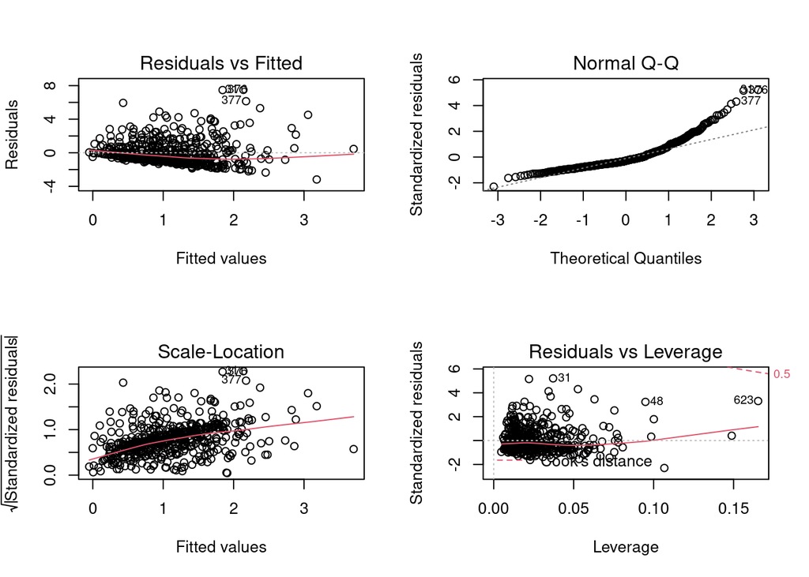

```r
# Split the plotting panel into a 2 x 2 grid
par(mfrow = c(2, 2))

# plot the four diagnostics plots for WinShare
plot(newmodel_WS)
```

WinShare linear regression model deviations

```r
#prediction
#WS_test_data <- test_data[, c("college_G", "college_FGA",  "college_2PA", "college_3P", "college_3PA",  "college_DRB", "college_TRB", "college_AST", "college_STL", "college_BLK", "college_TOV", "college_PTS")]

#prediction_WS <- predict(newmodel_WS, WS_test_data, type="response")
#prediction_WS

WinShare_SSE <- sum((fitted(newmodel_WS) - train_data$nba_WS)^2)
print(paste("WinShare model: Sum of the Squared Error (SSE) is: ", round(WinShare_SSE,2)))
```

```
## [1] "WinShare model: Sum of the Squared Error (SSE) is:  1076.88"
```

```r
WinShare_SSR <- sum((fitted(newmodel_WS) - mean(train_data$nba_WS))^2)
print(paste("WinShare model: Sum of the Squares Regression (SSR) is: ", round(WinShare_SSR,2)))
```

```
## [1] "WinShare model: Sum of the Squares Regression (SSR) is:  168.34"
```

```r
newmodel_VORP <- lm(formula = nba_VORP ~ college_MP + college_FG + college_FGA + college_2PA +
                                         college_3PA + college_FT + college_FTA + college_DRB +
                                         college_AST + college_STL + college_BLK + college_TOV + college_3P.,
                    data = as.data.frame(train_data))

summary(newmodel_VORP)
```

```
##
## Call:
## lm(formula = nba_VORP ~ college_MP + college_FG + college_FGA +
##     college_2PA + college_3PA + college_FT + college_FTA + college_DRB +
##     college_AST + college_STL + college_BLK + college_TOV + college_3P.,
##     data = as.data.frame(train_data))
##
## Residuals:
##     Min      1Q  Median      3Q     Max
## -1.5776 -0.2920 -0.1079  0.1331  3.7128
##
## Coefficients:
##              Estimate Std. Error t value Pr(>|t|)
## (Intercept)  0.247596   0.156251   1.585 0.113687
## college_MP  -0.017666   0.008737  -2.022 0.043725 *
## college_FG   0.072597   0.066247   1.096 0.273668
## college_FGA -2.274525   0.756017  -3.009 0.002757 **
## college_2PA  2.246925   0.752548   2.986 0.002967 **
## college_3PA  2.247759   0.754983   2.977 0.003050 **
## college_FT   0.207170   0.089327   2.319 0.020785 *
## college_FTA -0.113975   0.075563  -1.508 0.132097
## college_DRB  0.101767   0.026373   3.859 0.000129 ***
## college_AST  0.100138   0.028913   3.463 0.000579 ***
## college_STL  0.215304   0.072020   2.990 0.002932 **
## college_BLK  0.112160   0.050803   2.208 0.027716 *
## college_TOV -0.233703   0.064310  -3.634 0.000308 ***
## college_3P. -0.751876   0.322194  -2.334 0.020011 *
## ---
## Signif. codes:  0 '***' 0.001 '**' 0.01 '*' 0.05 '.' 0.1 ' ' 1
##
## Residual standard error: 0.5727 on 500 degrees of freedom
## Multiple R-squared:  0.1342, Adjusted R-squared:  0.1117
## F-statistic: 5.961 on 13 and 500 DF,  p-value: 2.413e-10
```

Plot the VORP graphs

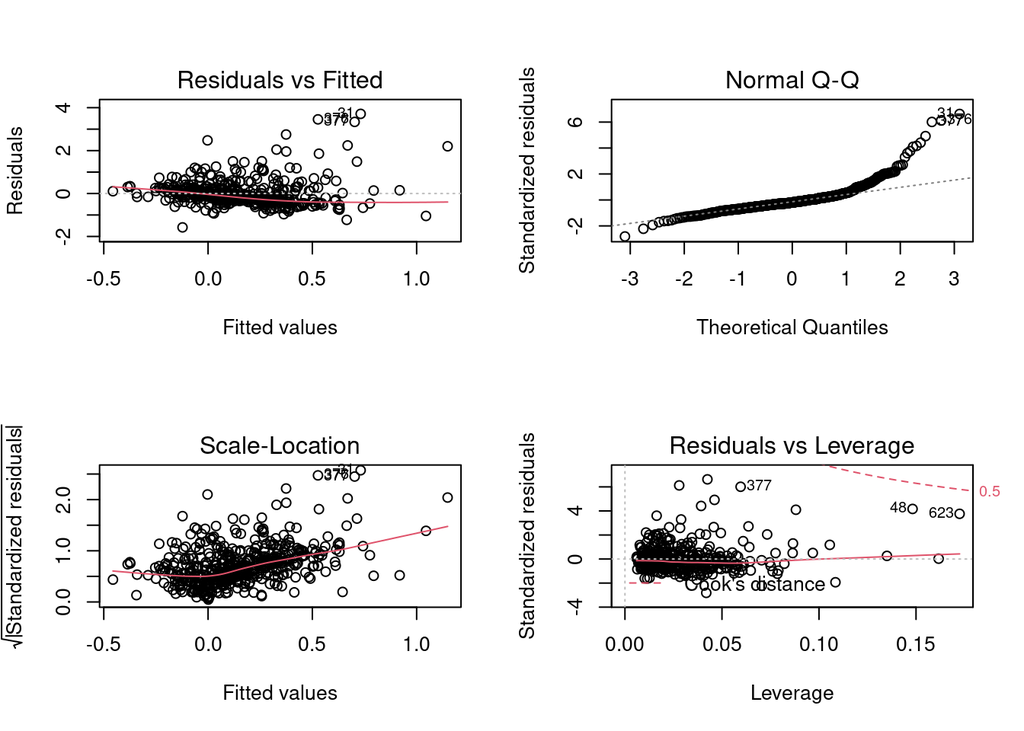

```r
# Split the plotting panel into a 2 x 2 grid
par(mfrow = c(2, 2))

# plot the four diagnostics plots for VORP
plot(newmodel_VORP)
```

VORP linear regression model deviations

```r
#prediction
#VORP_test_data <- test_data[, c("college_MP", "college_FG", "college_FGA",  "college_2PA", "college_3PA",  "college_FT", "college_FTA", "college_DRB", "college_AST", "college_STL", "college_BLK", "college_TOV", "college_3P.")]

#prediction_VORP <- predict(newmodel_VORP, VORP_test_data, type="response")
#prediction_VORP

VORP_SSE <- sum((fitted(newmodel_VORP) - train_data$nba_VORP)^2)
print(paste("VORP model: Sum of the Squared Error (SSE) is: ", round(VORP_SSE,2)))
```

```
## [1] "VORP model: Sum of the Squared Error (SSE) is:  164.01"
```

```r
VORP_SSR <- sum((fitted(newmodel_VORP) - mean(train_data$nba_VORP))^2)
print(paste("VORP model: Sum of the Squares Regression (SSR) is: ", round(VORP_SSR,2)))
```

```
## [1] "VORP model: Sum of the Squares Regression (SSR) is:  25.42"
```